# Лабораторная работы №6

Операционные системы

Павлова Т. Ю.

Российский университет дружбы народов, Москва, Россия

# Цель работы

Целью данной работы является приобретение практических навыков взаимодействия пользователя с системой посредством командной строки.

# Задание

1. Определить полное имя домашнего каталога
2. Выполнить требуемые действия для выполнения лабораторной работы
3. Использовать команду man
4. Использовать команду history

# Выполнение лабораторной работы

Целью данной работы является приобретение практических навыков взаимодействия пользователя с системой посредством командной строки.

# Задание

1. Определить полное имя домашнего каталога
2. Выполнить требуемые действия для выполнения лабораторной работы
3. Использовать команду man
4. Использовать команду history

# Выполнение лабораторной работы

# Работа с домашним каталогом

Определю полное имя домашнего каталога. Перехожу в каталог /tmp. Вывожу на экран содержимое этого каталога (рис. 1).

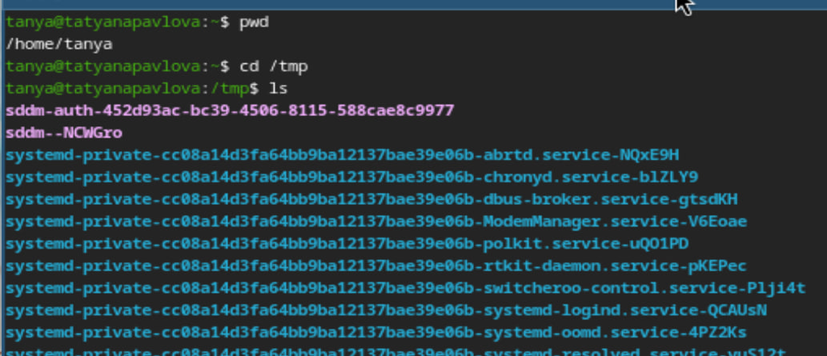

pwd

# Работа с домашним каталогом

Далее использую команду ls с разными опциями (чтобы отразить имена скрытых файлов - ls с опцией a) (рис. 2).

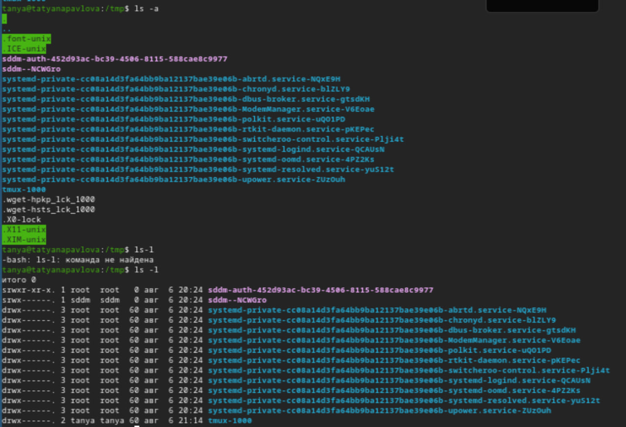

ls с опциями

# Работа с домашним каталогом

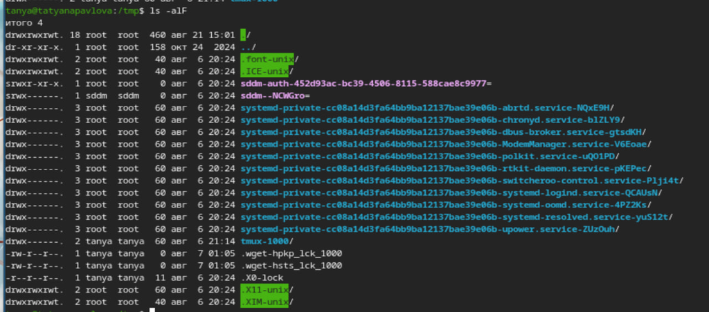

ls с опциями

# Работа с каталогом /var/spool

Определяю есть ли в каталоге /var/spool подкаталог с именем cron. У меня он есть (рис. 4).

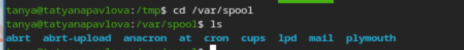

Проверка наличия в каталоге

# Работа с домашним каталогом

Перехожу в свой домашний каталог и вывожу на экран его содержимое. Владелец файлов - я (рис. 5).

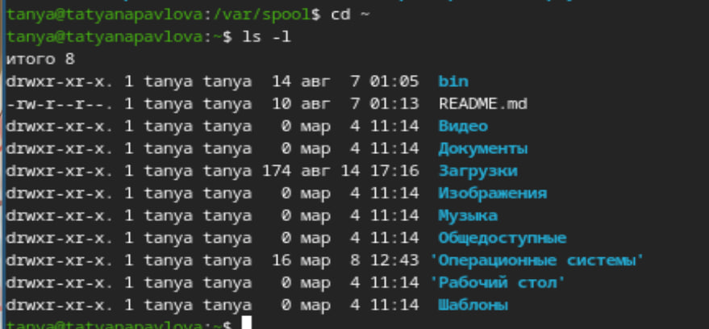

Содержимое домашнего каталога

# Создание каталогов

В домашнем каталоге создаю новый каталог с именем newdir. В каталоге ~/newdir создаю новый каталог с именем morefun (рис. 6).

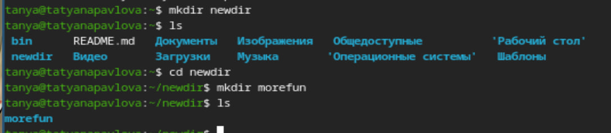

Создание каталогов

# Создание каталогов

В новом каталоге создаю одной командой три новых каталога с именами letters, memos, misk. Затем удаляю эти каталоги (рис. 7).

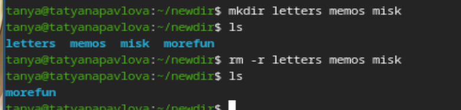

Создание каталогов

# Удаление каталогов

Пробую удалить ранее созданный каталог ~/newdir командой rm. Проверяю, был ли каталог удален. Удаляю каталог ~/newdir/morefun из домашнего каталога (рис. 8).

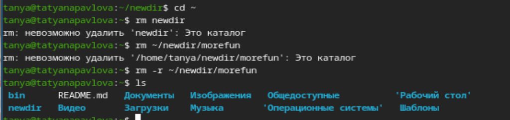

Удаление каталогов

# Команда man

С помощью команды man определяю, какую опцию команды ls нужно использовать для просмотра содержимого не только указанного каталога, но и подкаталогов, входящих в него. С помощью команды man определяю набор опций ls, позволяющий отсортировать по времени последнего изменения выводимый список содержимого каталога с развернутым описанием файлов (рис. 9), (рис. 10).

# Команда man (ls -R)

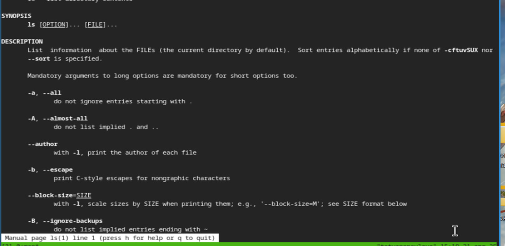

ls -R

# Команда man (ls -time-style)

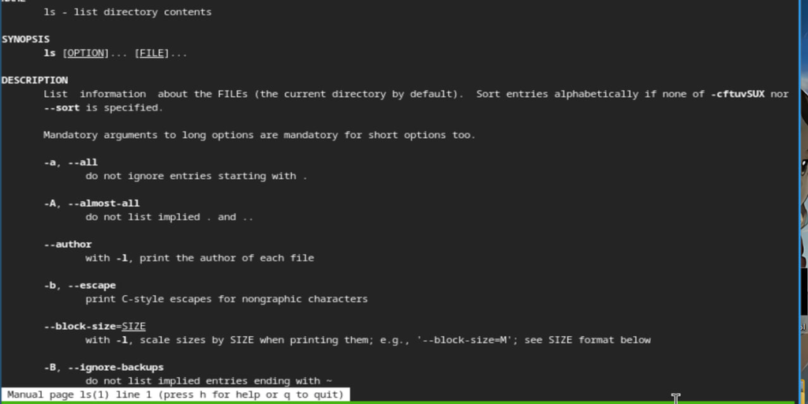

ls -time-style

# Команда man

Использую команду man для просмотра описания следующих команд: cd, pwd, mkdir, rmdir, rm (рис. 11), (рис. 12), (рис. 13), (рис. 14), (рис. 15).

# Команда man (cd)

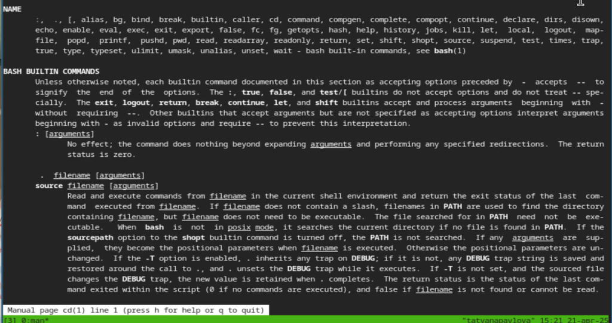

cd

# Команда man (pwd)

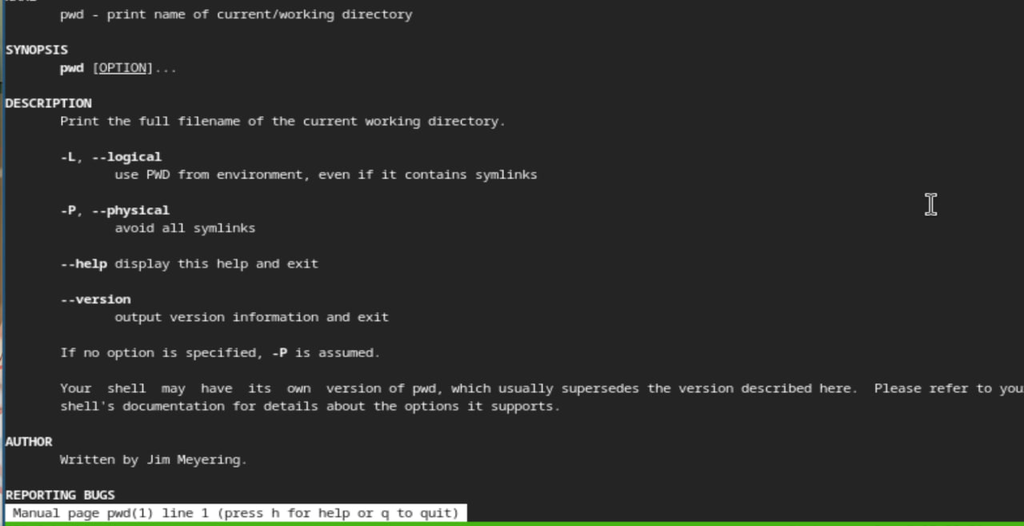

pwd

# Команда man (mkdir)

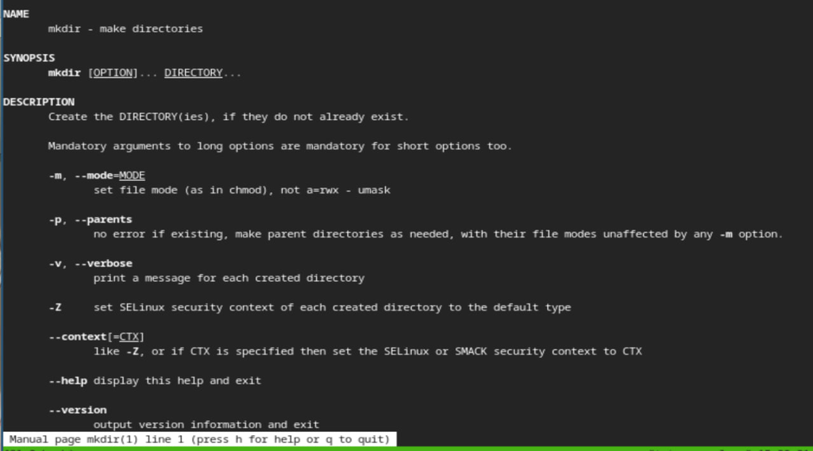

mkdir

# Команда man (rmdir)

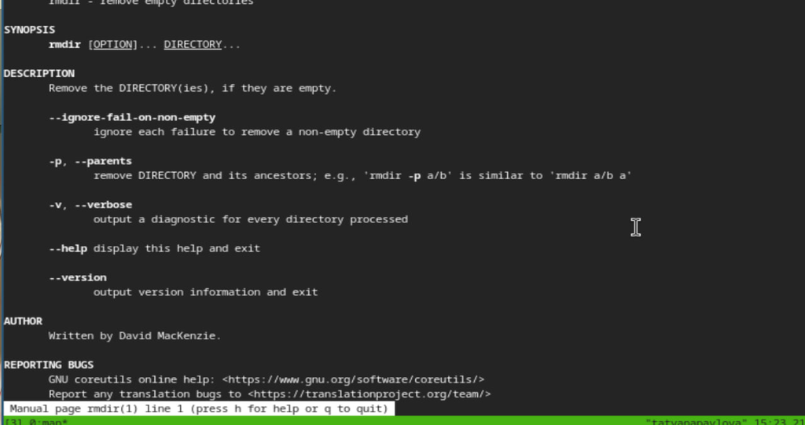

rmdir

# Команда man (rm)

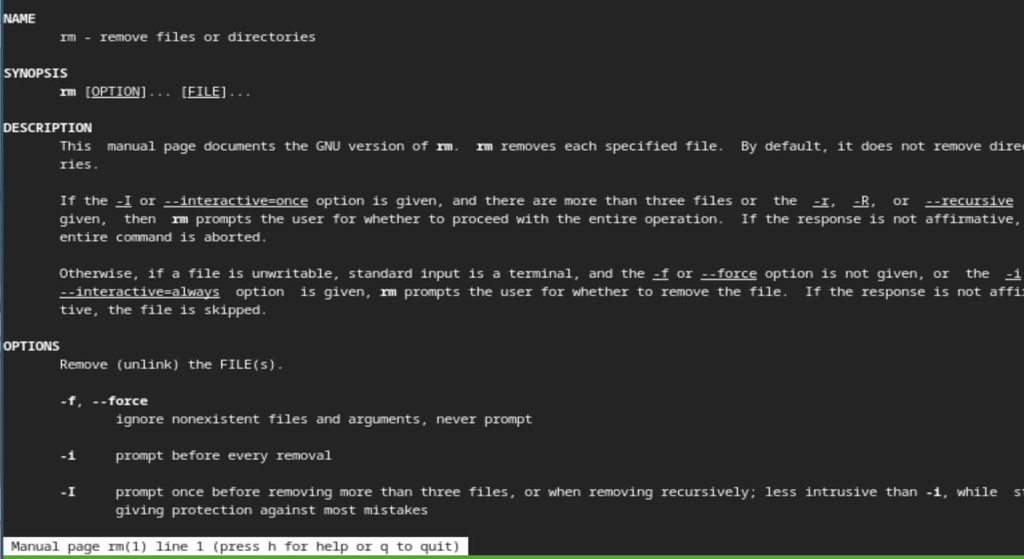

rm

# Команда history

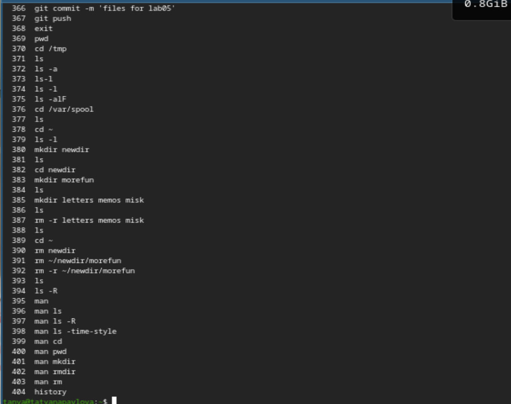

history

# Выполнение модификаций и команд

Выполняю модификацию и исполнение нескольких команд из буфера команд (рис. 17)

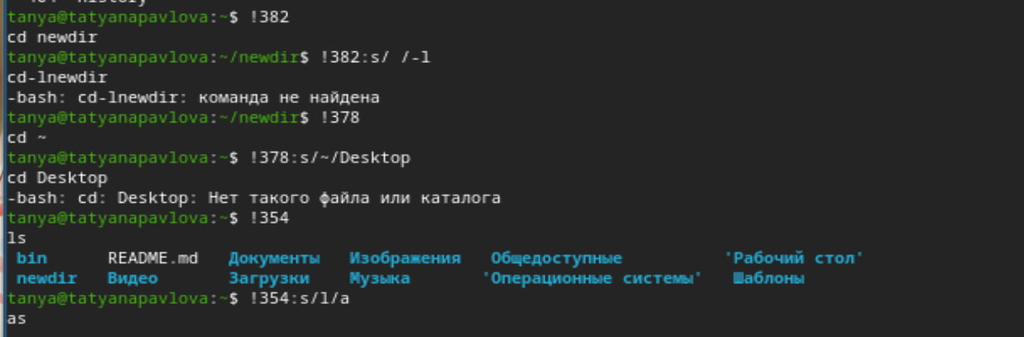

Модификация команд

# Выводы

При выполнении данной лабораторной работы, я приобрела практические навыки взаимодействия пользователя с системой посредством командной строки.